# Module 5b: Human Capital & Stakeholders

MHIA 6160 | Value & Quality in Healthcare | 1.50 | W27

Dr. Cameron B. Chiarot

## Module 5b.1

### Human Capital Dynamics

## Introduction to Human Capital Dynamics

**Workforce Optimization in Complex Health Systems**

- **Focus:** Moving beyond traditional administrative personnel management to strategic workforce optimization in complex health systems.
- **Human Capital Challenge:** Healthcare organizations face intense resource constraints, high burnout rates, and increasing operational demands.
- **Strategic Shift:** Human capital is not a static cost centre; it is the primary driver of innovation, quality, and clinical transformation.

**Key Learning Objective**

Understanding how leadership levers, psychological theory, and engagement structures directly impact organizational performance and retention.

## Motivation Theory: Locke & Latham’s Goal-Setting Theory

**Aligning Individual Performance with Organizational Goals**

- **Framework:** Goal-Setting Theory posits that specific and challenging goals, coupled with appropriate feedback, lead to higher performance.
- **Core Mechanisms:**
  - **Specificity:** Explicit targets clarify expectations, whereas vague goals fail to direct focus.
  - **Difficulty:** Stretch goals drive higher performance (prerequisites: ability & support.
  - **Commitment:** Employees must internalize goals that align with metrics.
- **Application:** Translate targets into clinical milestones without triggering *moral injury*.

## Defining Moral Injury in Healthcare Leadership

**Understanding the Root Cause of Healthcare Strain**

- **Definition:** Moral injury occurs when individuals are repeatedly asked to act or witness actions that violate their core professional values, ethical standards, or sense of duty.
- **Distinction from Burnout:** While general burnout stems from chronic operational exhaustion and heavy workloads, moral injury specifically involves a violation of conscience and professional integrity.
- **Leadership Implication:** In healthcare settings, poorly designed performance targets or conflicting institutional mandates can inadvertently force clinicians into situations where they feel powerless to deliver optimal care.

## Integrating Terminology into Goal-Setting Theory

**Balancing Stretch Goals and Systemic Strain**

- **Connecting Theory to Reality:** When applying Locke & Latham’s GST, leaders must account for the unique operational pressures of clinical environments.
- **Avoiding Administrative Strain:** Setting aggressive performance targets without adequate support can exacerbate *values-based burnout* or *administrative burden*.
- **Leadership Takeaway:** Effective goal-setting requires providing the necessary tools, staffing, and operational bandwidth so that stretch goals inspire excellence.

**Practical Application**

Ensure performance metrics are paired with the resources required to achieve them.

## Operationalizing Workforce Engagement: The Executive Reality

**Examining Enterprise Engagement Survey Distributions**

## Employee Engagement Continuum (Gallop Inc. Poll)

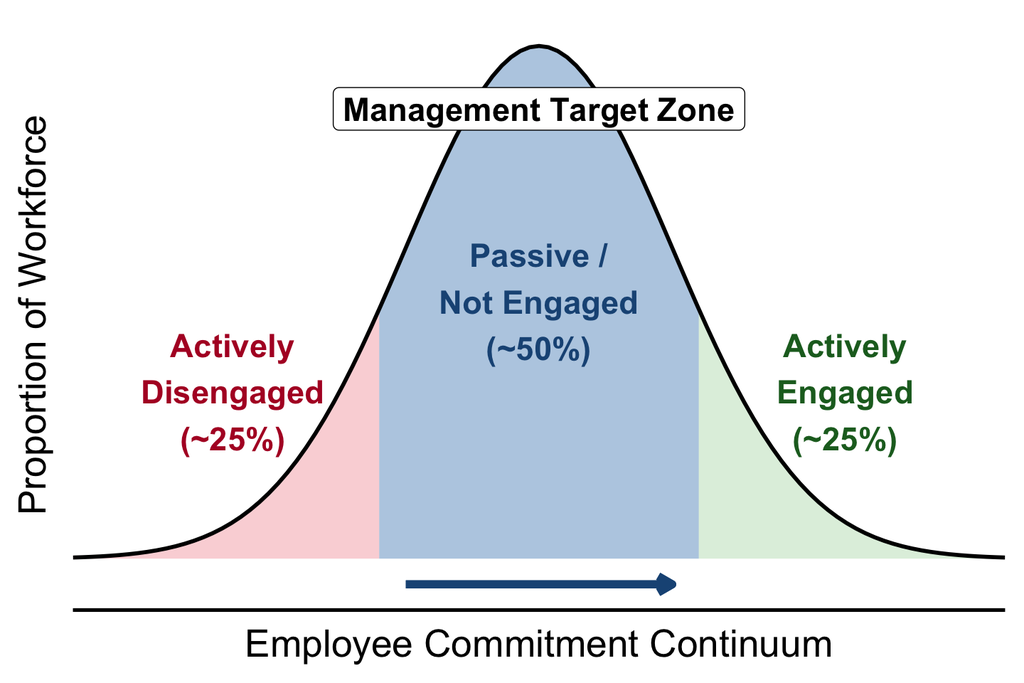

**Source:** Gallup Inc., 2026

## The Engagement Dilemma: Fixing vs. Fostering

**Strategic Allocation of Executive Capital and Attention**

- **The Pitfall of Remediation Obsession:** Over-allocating leadership capital to the actively disengaged often signals to high performers that underperformance is rewarded.
- **The Risk of Inequity:** According to Equity Theory, if top performers observe disproportionate resources flowing toward resistance management, perceived org. fairness drops, leading to recognition fatigue.
- **The Alternative Strategic Choice:** High-impact leadership focuses resources on protecting and empowering the actively engaged and leveraging them as peer-modelling nodes to pull the neutral 50% upward.

**Source:** Adams, 1963

## Module 5b.2

### Collaborative Leadership

## The Imperative of Collaborative Leadership

**Navigating Cross-Functional Boundaries in Health Systems**

- **The Reality of Modern Healthcare:** Delivery models span multiple clinical specialties, academic partners, & regional authorities,
- **Defining Collaborative Leadership:** A leadership style that engages diverse stakeholders across organizational silos, aligning shared purpose without relying on formal hierarchy.
- **Core Leadership Challenge:** Balancing distinct professional cultures that operate under divergent performance incentives.

## Interprofessional Dynamics: Bridging Professional Silos

**Aligning Divergent Mental Models & Clinical Incentives**

- **Professional Identity:** Healthcare workers are socialized into distinct professional silos with unique vocabularies & priorities.
- **Coordination Gap:** Siloed communication leads to fragmented care pathways, resource duplication, & operational friction.
- **Leadership Solution:**
  - Establish shared mental models through joint training & cross-disciplinary forums.
  - Translate admin. metrics into meaningful clinical impact narratives to secure buy-in.

## Multi-Institutional Ecosystems: Managing Complexity

**Leading Across Organizational & Jurisdictional Boundaries**

- **Complex Partnerships:** Modern initiatives frequently require collaboration between hospitals, universities, regional health authorities, & private sector.
- **Power Asymmetry:** Multi-institutional networks often lack a clear vertical chain of command, relying instead on negotiated alignment and reciprocal value exchanges.
- **Governance Challenges:** Divergent institutional KPIs can paralyze decision-making unless leadership actively designs clear governance & accountability structures.

**Governance Reality**

If institutional accountability is ambiguous at the design stage, collaborative initiatives default to bureaucratic gridlock.

## Collaborative Intelligence in Action

**Synthesizing Internal Human Capital & External Networks**

- **The Multiplier Effect:** True collaborative leadership links the internal workforce engagement strategies with external network execution.
- **Key Leadership Capabilities:**
  - **Empathy & Perspective-Taking:** Understand the operational constraints of partners
  - **Transparent Communication:** Build psychological safety across org. boundaries.
  - **Shared Vision Framing:** Unify disparate groups around a common objective.

Understanding how to lead across interprofessional and multi-institutional boundaries sets the stage for our applied stakeholder mapping exercise in Section 5b.3

## Module 5b.3

### Stakeholder Mapping

## Theory: Salience Framework & Power-Interest Grid

**Premise:** Stakeholder management requires evaluating actors across 3 attributes:

- **Power** (capacity to coerce or influence)
- **Legitimacy** (moral or legal entitlement)
- **Urgency** (time-sensitivity of claims)

**Strategic Matrix:** Plotting stakeholders prevents resource dispersion by categorizing:

- **Manage Closely** (High Power / High Interest)
- **Keep Satisfied** (High Power / Low Interest)
- **Keep Informed** (Low Power / High Interest)
- **Monitor** (Low Power / Low Interest)

**Source:** Mitchell, Agle, & Wood, 1997

## Salience Framework & Power-Interest Grid

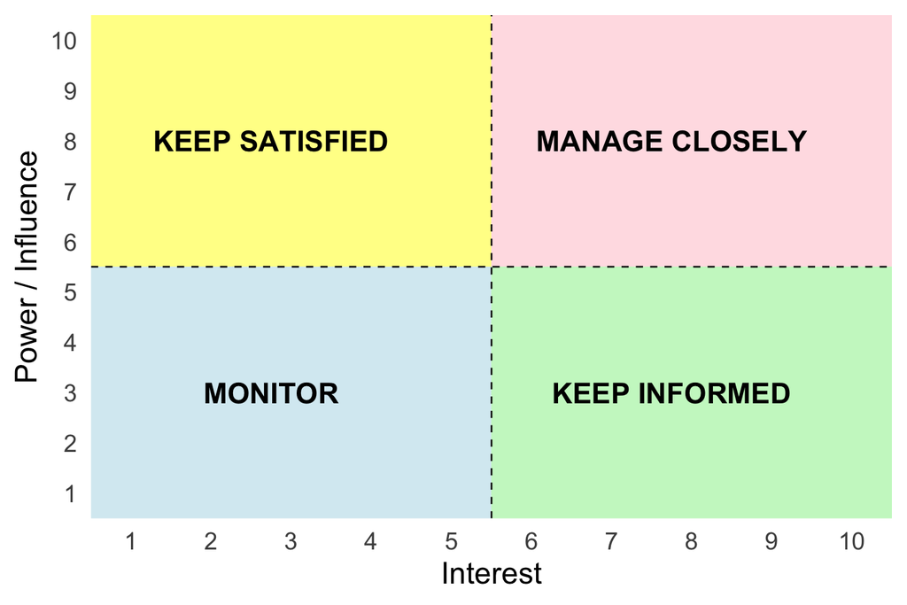

## The Public Lens: Regulatory and Population Mandates

**Balancing Stewardship, Equity, and Political Accountability**

- **Public Sector Priorities:** Governed by public funding transparency, population health outcomes, political risk mitigation, and strict adherence to ministry directives.
- **Vulnerability Trap:** Public health executives often over-index on political optics, leading to risk aversion that paralyzes innovative asset monetization.
- **Strategic Alignment:** Engaging public stakeholders requires demonstrating adherence to the *quadruple aim* and proving that commercial ventures cross-subsidize public clinical missions rather than degrading access.

## The Private Lens: Market Dynamics and Capital ROI

**Navigating Private Incentives, Risk-Adjusted Returns, & Speed**

- **Private Sector Priorities:** Governed by capital efficiency, speed-to-market, IP protection, and scalable revenue streams.
- **Cultural Friction:** Private partners often experience frustration with public sector consensus-driven, bureaucratic decision-making cycles.
- **Strategic Synthesis:** Successful hybrid ventures require translating public clinical value propositions into clear, defensible private-payer metrics without compromising ethical care standards.

## Module 5b Summary: Human Capital & Stakeholders

**Key Strategic Takeaways for Healthcare Leaders**

- **Workforce Optimization:** Treat human capital as a strategic asset; focus executive energy on anchoring and empowering high-engagement tiers rather than chasing disengagement.
- **Collaborative Leadership:** Build shared mental models and governance structures across interprofessional and multi-institutional silos to combat bureaucratic gridlock.
- **Stakeholder Mapping:** Rigorously categorize actors using Power-Interest dynamics to preemptively secure alignment before executing structural commercial initiatives.

## Week 6 Deliverable: Capstone Summit (**Weight: 20%**)

**Presentation Schedule**

**Total Duration:** 180 min (incl. 20 min intermission)  
**Format:** 20 min / Group (10 min present + 10 min Q&A)

**Summit A:**

1. **Group 2**
2. **Group 5**
3. **Group 1**

**Summit B:**

4. **Group 3**
5. **Group 6**
6. **Group 4**

## Module 5b.3 Class Exercise: Case Study

**Applied Strategic Analysis**

- **Case Study:** *Chasing Half-Lives: Stakeholder Dynamics in Nuclear Medicine* explores leveraging excess cyclotron production via export or public-private partnerships.
- **Objective:** Evaluate internal priorities, external regulatory constraints, and financial targets to pitch an aligned commercial model to the Chief Innovation Officer.
- **Accessing Materials:** Open the interactive Case Study via the course portal.

## Module 5b.3 Class Exercise: Case Study

**Group Work Objectives (60 Minutes Total)**

- **Slide 1:** Stakeholder Map
- **Slide 2:** Strategy Pitch

**Time Allocation**

- **00-05 min:** Individual case reading.
- **05-20 min:** Group collaboration & R plot.
- **20-60 min:** Rapid-fire group pitches & Q&A.

## Module 5b.3 Class Exercise: Case Study

**Presentation Schedule**

1. **Group 4**
2. **Group 1**
3. **Group 6**
4. **Group 2**
5. **Group 5**
6. **Group 3**